# 6306: Week 3 FLS

Matt Farrow

9/6/2020

## Setup

```r
# Read data
df <- read_csv(here::here("6306", "week 03", "FIFA Players.csv"),
    col_types = cols(X1 = col_character(),
        ID = col_character(), Joined = col_date(format = "%d-%b-%y"),
        `Contract Valid Until` = col_number()))
# Clean column names
df <- janitor::clean_names(df)

# Convert height to cm
df <- df %>%
 separate(height, c('feet', 'inches'), "'", convert = TRUE) %>%
 mutate(height_cm = (12*feet + inches)*2.54)

# Convert weight to lbs
df <- df %>%
 mutate(weight = str_sub(weight, 1, 3))
```

## Part 1

**Using the FIFA player data set, filter the data set to create a dataframe that has just the Left Midfielders (LM) and Left Forwards (LF).**

```r
df_subset <- df %>%
 filter(position %in% c("LM", "LF"))
```

**Use Ggally and ggpairs() and the dataset you created above above, to plot the categorical variable Position (LM and LF), versus the continuous variables Acceleration and Agility.**

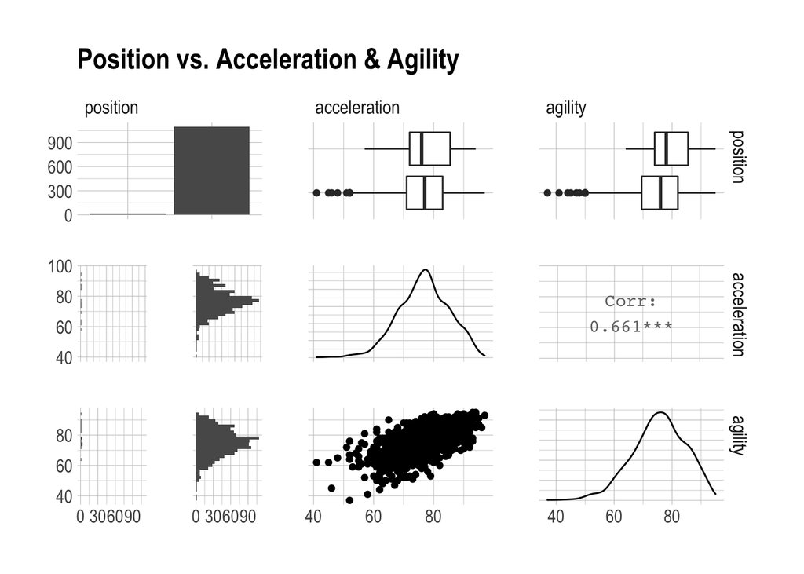

```r
df_subset %>%
  select(position, acceleration, agility) %>%
  ggpairs() +
  labs(title = "Position vs. Acceleration & Agility") +
  theme_ipsum()
```

**Given the plot above, what relationships do you see? Comment on these.**

- There appears to be a linear relationship between acceleration and agility.
- There is also a striking difference between the number of players are each of these positions.
- Although the medians of the box plots comparing acceleration and position and the boxplots comparing agility and position appear relatively similar, one of the positions shows a strong left-skewed distribution with a number of outliers.

**Your client would like to formally test if the mean agility rating of left midfielders is different than that of the left forwards. Perform a 6–step t-test to test for the difference in these means. (You may skip step 2 (draw and shade) if you like. If you are unfamiliar with the 6-step hypothesis test, see Stat 1 slides or the Bridge Course to review the 6-step hypothesis test.)**

$H_0: μ(agility_{lm}) = μ(agility_{lf})$ $H_a: μ(agility_{lm}) ≠ μ(agility_{lf})$

```r
t.test(agility ~ position, data = df_subset)
```

```
##
##  Welch Two Sample t-test
##
## data:  agility by position
## t = 2.0126, df = 14.48, p-value = 0.06314
## alternative hypothesis: true difference in means is not equal to 0
## 95 percent confidence interval:
##  -0.2716132  8.9821155
## sample estimates:
## mean in group LF mean in group LM
##         79.73333         75.37808
```

**Are the assumptions of this test reasonably met? If you have not had Stat 1, simply create a histogram of the agility scores for both groups (LM and LF) and given what you know about the CLT, comment on if you believe the sampling distribution of sample means (of your sample size) will be reasonably normal. In addition, does there look like there is significant visual evidence to suggest the standard deviations are different?**

With only 15 left forwards in the data set, there is not enough data to satisfy the needs of the Central Limit Theorem. As observed in the ggpairs() example above, there is significant visual evidence to suggest the standard deviations are different.

## Part 2

**Select/create at least 2 categorical variables and select two continuous variables and perform an EDA. Also, at least one of the categorical variables should be created from a continuous variable (using the cut() function).**

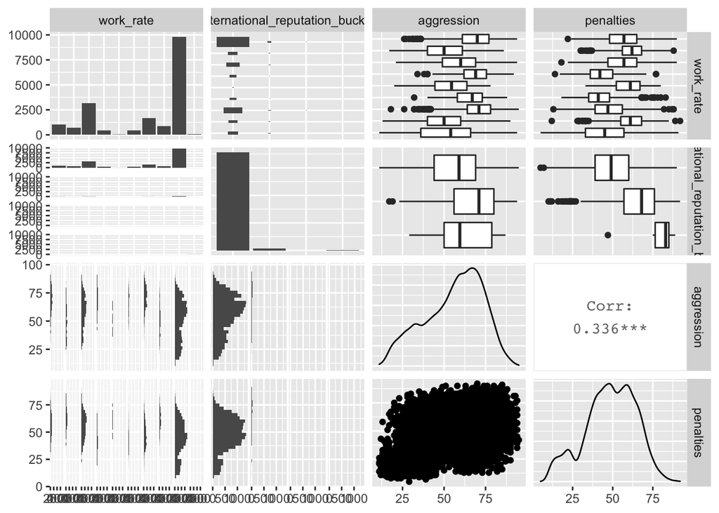

```r
df %>%
  mutate(international_reputation_bucket = cut(
    international_reputation,
    breaks = c(0, 2, 4, Inf),
    labels = c("Low", "Medium", "High")
  )) %>%
  select(work_rate,
         international_reputation_bucket,
         aggression,
         penalties) %>%
  ggpairs()
```

**Use these variables to explore the data and tell a story of what you discovered similar to what was shown in the asynch videos. You do not need to go so far as to use linear regression, but let your curiosity guide you along the way and feel free to use methods you are familiar with that are appropriate to answering those questions. Your evidence could be purely visual or could include additional methods, it is up to you…just do your best and have fun!**

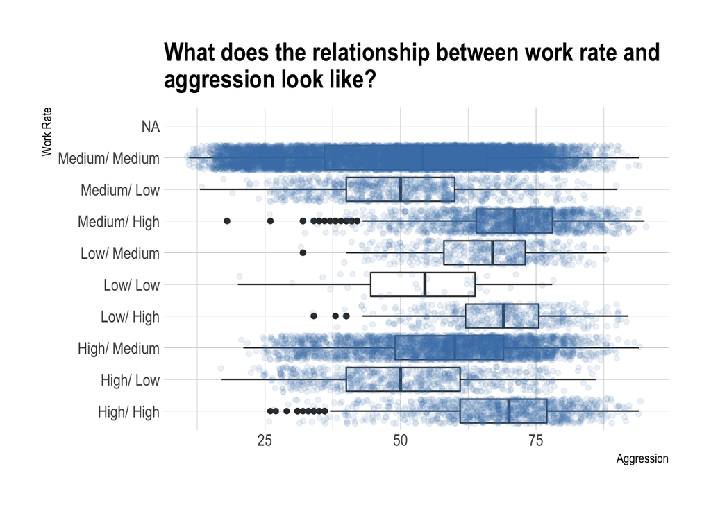

```r
df %>%
  ggplot(aes(aggression, work_rate)) +
  geom_boxplot() +
  geom_jitter(color = "steelblue", alpha = 0.1) +
  labs(title = "What does the relationship between work rate and\naggression look like?",
       x = "Aggression",
       y = "Work Rate") +
  theme_ipsum()
```

As we’d expect, the vast majority of players fit into the Medium/Medium category, and very few fit in the Low/Low category. One thing I find interesting is the fact that the three categories with “High” as the 2nd component have the three highest medians of aggression. I wonder if those players with high aggression have any similarity to their position?

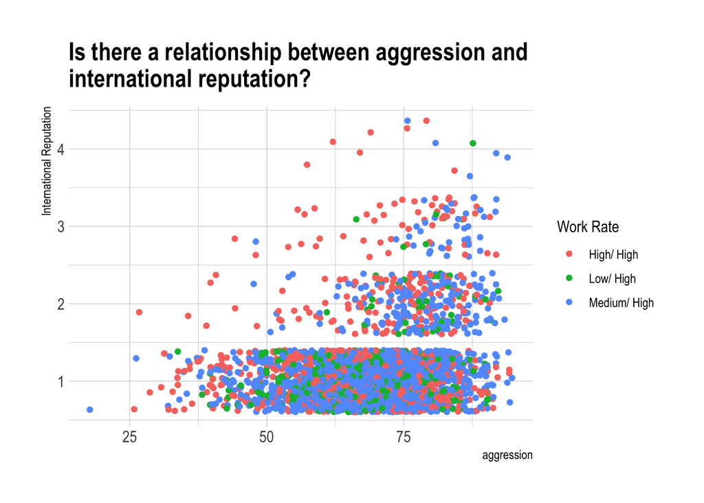

```r
df %>%
  filter(work_rate %in% c("Medium/ High", "Low/ High", "High/ High")) %>%
  ggplot(aes(aggression, international_reputation, color = work_rate)) +
  geom_jitter() +
  labs(title = "Is there a relationship between aggression and\ninternational reputation?",
       x = "aggression",
       y = "International Reputation",
       color = "Work Rate") +
  theme_ipsum()
```

Interestingly, the players who fall into these higher aggression ranges appear to fall, by and large, into what I assume is a lower international reputation.